# R Notebook

```r
library(tidyverse)
```

#### 1.

```r
backpack <- CodeClanData::backpack

str(backpack)
```

```
'data.frame':   100 obs. of  9 variables:
 $ backpack_weight: int  9 8 10 6 8 5 8 4 5 2 ...
 $ body_weight    : int  125 195 120 155 180 240 170 185 130 120 ...
 $ ratio          : num  0.072 0.041 0.0833 0.0387 0.0444 ...
 $ back_problems  : int  1 0 1 0 0 0 0 1 0 0 ...
 $ major          : Factor w/ 41 levels "Act.","Aero",..: 9 32 19 16 18 20 13 7 9 9 ...
 $ year           : int  3 5 4 6 2 0 3 5 4 5 ...
 $ sex            : Factor w/ 2 levels "Female","Male": 1 2 1 2 1 2 2 1 1 1 ...
 $ status         : Factor w/ 2 levels "G","U": 2 2 2 1 2 1 2 2 2 2 ...
 $ units          : int  13 12 14 0 14 0 15 18 14 8 ...
```

#### 2.

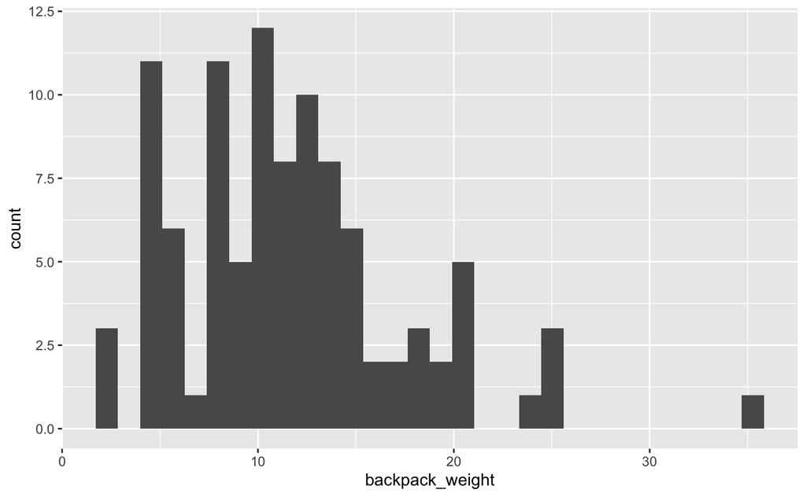

```r
ggplot(backpack) +
  aes(x = backpack_weight) +
  geom_histogram()
```

The histogram shows the spread of the number of students carrying different backpack weights. It shows a clear curve where more students carry backpacks weighing approximately the median weight. Most students carry a 10 pound backpack.

#### 3.

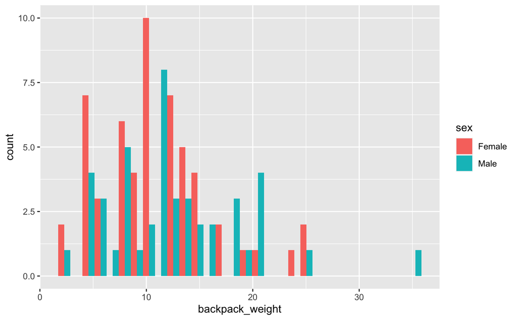

```r
ggplot(backpack) +
  aes(x = backpack_weight, fill = sex) +
  geom_histogram(position = "dodge")
```

The histogram shows that girls tend to carry lighter backpacks, the heaviest backpack carried weighed 25 pounds for a girl, and 35 pounds for a boy.

#### 4.

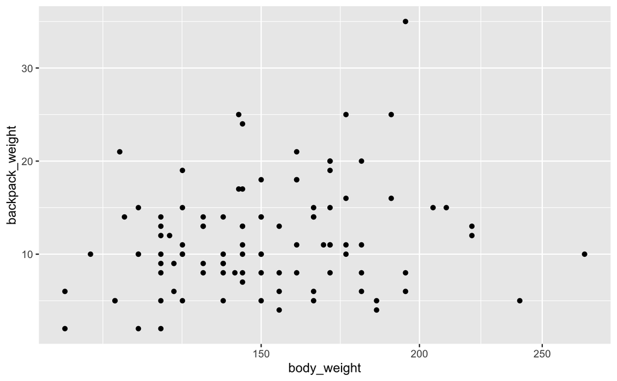

```r
ggplot(backpack)+
  aes(x = body_weight, y = backpack_weight)+
  geom_point()+
  scale_x_log10()
```

There seems to be some correlation between increasing body weight and increasing backpack weight, however the values that correspond to body weight values of more than 200 pounds has a much weaker correlation.

#### 5.

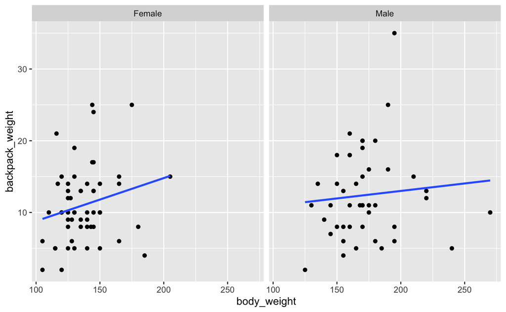

```r
ggplot(backpack)+
  aes(x = body_weight, y = backpack_weight)+
  geom_point()+
  facet_wrap(~sex)+
  geom_smooth(method = "lm", se = FALSE)
```

The correlation between body weight and backpack weight is quite weak for women, but there seems to be no correlation between body weight and backpack weight for men.

#### 6.

```r
backpack <- backpack %>%
  mutate(back_problems = factor(back_problems, levels = c("1", "0")))
```

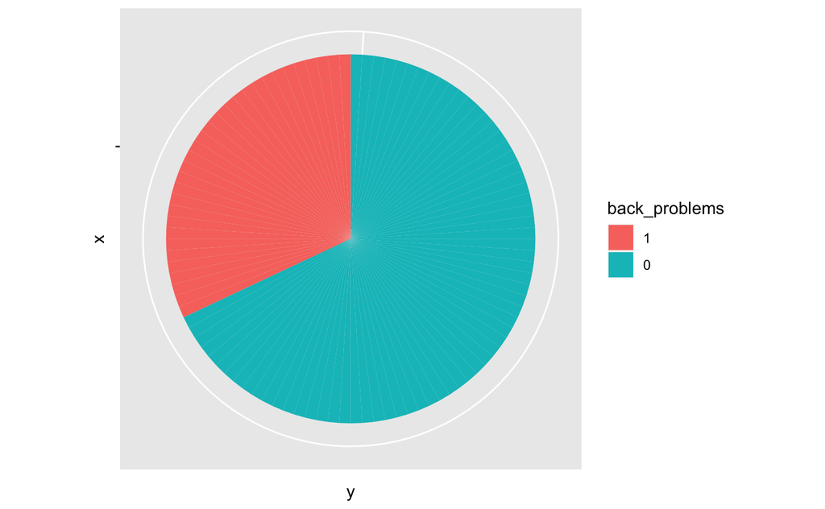

```r
ggplot(backpack)+
  aes(x = "", y = "backpack_probkems",  fill = back_problems) +
  geom_bar(stat = "identity", width = 1)+
  coord_polar("y", start = 0)
```

```r
NA
```

There is clearly a larger proportion of people without back problems than the ones who do, though I can’t seem to put labels on the pie chart and identify the exact percentage.

####7.

I don’t completely understand this question – and it’s really late already so i’m going to bed.